# Mercari Price Suggestion Challenge

*Can you automatically suggest product prices to online sellers?*

## 1. Business Understanding

It can be hard to know how much something’s really worth. Small details can mean big differences in pricing. For example, one of these sweaters cost 335 dollars and the other cost 9.99 dollars. Can you guess which one’s which?

[figure not shown]

Product pricing gets even harder at scale, considering just how many products are sold online. Clothing has strong seasonal pricing trends and is heavily influenced by brand names, while electronics have fluctuating prices based on product specs.

Mercari, Japan’s biggest community-powered shopping app, knows this problem deeply. They’d like to offer pricing suggestions to sellers, but this is tough because their sellers are enabled to put just about anything, or any bundle of things, on Mercari's marketplace.

The goal is to build an algorithm that automatically suggests the right product prices

## 2. Data Understanding

```python
import warnings
warnings.filterwarnings('ignore')
import pandas as pd
import numpy as np
import seaborn as sns
import re
import pickle
import string
import matplotlib.pyplot as plt
from scipy import stats
from scipy.stats import iqr
from scipy.sparse import csr_matrix
from tqdm import tqdm

from sklearn.preprocessing import MinMaxScaler
from sklearn.preprocessing import OneHotEncoder
from sklearn.preprocessing import LabelEncoder, LabelBinarizer
from sklearn.preprocessing import StandardScaler
from sklearn.feature_selection import chi2
from sklearn.feature_selection import mutual_info_regression
from sklearn.feature_selection import SelectKBest
from sklearn.feature_extraction.text import CountVectorizer

from sklearn.compose import ColumnTransformer
from sklearn.impute import SimpleImputer
from sklearn.pipeline import Pipeline
from nltk.stem import PorterStemmer
from nltk.tokenize import word_tokenize
import nltk

from sklearn.model_selection import cross_validate
from sklearn.model_selection import cross_val_score
from sklearn.model_selection import KFold
from sklearn.model_selection import train_test_split
from sklearn.model_selection import GridSearchCV

from sklearn.datasets import make_regression
from sklearn.metrics import mean_squared_error
from sklearn.metrics import mean_absolute_error
from sklearn.metrics import make_scorer
from sklearn.metrics import r2_score

from matplotlib import pyplot as plt
from sklearn.ensemble import RandomForestRegressor, AdaBoostRegressor
from sklearn.tree import DecisionTreeRegressor, plot_tree
from sklearn.linear_model import Ridge, Lasso
from sklearn.linear_model import LinearRegression
from sklearn.neural_network import MLPRegressor
```

```python
file_path = r'D:\USERS\Andjela\Downloads\project_data\train.tsv'
train=pd.read_csv(file_path, sep='\t')
```

```python
train.head(20)
```

|  | train_id | name | item_condition_id | category_name | brand_name | price | shipping | item_description |
| --- | --- | --- | --- | --- | --- | --- | --- | --- |
| 0 | 0 | MLB Cincinnati Reds T Shirt Size XL | 3 | Men/Tops/T-shirts | NaN | 10.0 | 1 | No description yet |
| 1 | 1 | Razer BlackWidow Chroma Keyboard | 3 | Electronics/Computers & Tablets/Components & P... | Razer | 52.0 | 0 | This keyboard is in great condition and works ... |
| 2 | 2 | AVA-VIV Blouse | 1 | Women/Tops & Blouses/Blouse | Target | 10.0 | 1 | Adorable top with a hint of lace and a key hol... |
| 3 | 3 | Leather Horse Statues | 1 | Home/Home Décor/Home Décor Accents | NaN | 35.0 | 1 | New with tags. Leather horses. Retail for [rm]... |
| 4 | 4 | 24K GOLD plated rose | 1 | Women/Jewelry/Necklaces | NaN | 44.0 | 0 | Complete with certificate of authenticity |
| 5 | 5 | Bundled items requested for Ruie | 3 | Women/Other/Other | NaN | 59.0 | 0 | Banana republic bottoms, Candies skirt with ma... |
| 6 | 6 | Acacia pacific tides santorini top | 3 | Women/Swimwear/Two-Piece | Acacia Swimwear | 64.0 | 0 | Size small but straps slightly shortened to fi... |
| 7 | 7 | Girls cheer and tumbling bundle of 7 | 3 | Sports & Outdoors/Apparel/Girls | Soffe | 6.0 | 1 | You get three pairs of Sophie cheer shorts siz... |
| 8 | 8 | Girls Nike Pro shorts | 3 | Sports & Outdoors/Apparel/Girls | Nike | 19.0 | 0 | Girls Size small Plus green. Three shorts total. |
| 9 | 9 | Porcelain clown doll checker pants VTG | 3 | Vintage & Collectibles/Collectibles/Doll | NaN | 8.0 | 0 | I realized his pants are on backwards after th... |
| 10 | 10 | Smashbox primer | 2 | Beauty/Makeup/Face | Smashbox | 8.0 | 1 | 0.25 oz Full size is 1oz for [rm] in Sephora |
| 11 | 11 | New vs pi k body mists | 1 | Beauty/Fragrance/Women | Victoria's Secret | 34.0 | 0 | (5) new vs pink body mists (2.5 oz each) Fresh... |
| 12 | 12 | Black Skater dress | 2 | Women/Dresses/Above Knee, Mini | rue | 16.0 | 0 | Xl, great condition |
| 13 | 13 | Sharpener and eraser | 1 | Other/Office supplies/School Supplies | Scholastic | 4.0 | 1 | No description yet |
| 14 | 14 | HOLD for Dogs2016 Minnetonka boots | 3 | Women/Shoes/Boots | UGG Australia | 43.0 | 0 | Authentic. Suede fringe boots. Great condition... |
| 15 | 15 | Sephora tarte birthday gift | 1 | Beauty/Makeup/Makeup Sets | Tarte | 11.0 | 1 | Brand new. Deluxe travel size products. Contai... |
| 16 | 16 | Glitter Eyeshadow | 1 | Beauty/Makeup/Eyes | Wet n Wild | 6.0 | 1 | 2 glitter eyeshadows; one in Brass and one in ... |
| 17 | 17 | New: Baby K'tan active baby carrier | 1 | Kids/Gear/Backpacks & Carriers | NaN | 29.0 | 1 | Brand new in box Size: Medium Color: Coral Ret... |
| 18 | 18 | Too Faced Limited "Merry Macaroons" | 1 | Beauty/Makeup/Makeup Palettes | Too Faced | 25.0 | 1 | This AUTHENTIC pallete by Too Faced is brand n... |
| 19 | 19 | Cream/ Beige Front Cross Shirt | 2 | Women/Tops & Blouses/Blouse | Anthropologie | 27.0 | 0 | Fancy, dressy or casual! Dress it up or down 1... |

### 2.1. Data Dictionary

Train and test data sets consist of 7 (8 in train set, including target variable) columns, representing following data:

- train_id or test_id - the id of the listing
- name - the title of the listing. Note that we have cleaned the data to remove text that look like prices (e.g. 20USD) to avoid leakage. These removed prices are represented as [rm]
- item_condition_id - the condition of the items provided by the seller
- category_name - category of the listing
- brand_name
- shipping - 1 if shipping fee is paid by seller and 0 by buyer
- item_description - the full description of the item. Note that we have cleaned the data to remove text that look like prices (e.g. 20USD) to avoid leakage. These removed prices are represented as [rm]
- price - the price that the item was sold for. This is the target variable that you will predict. The unit is USD. This column doesn't exist in test.tsv since that is what you will predict.

```python
X = train.drop(columns='price')
X.drop(columns=['train_id'], inplace=True)
```

```python
X.head(10)
```

|  | name | item_condition_id | category_name | brand_name | shipping | item_description |
| --- | --- | --- | --- | --- | --- | --- |
| 0 | MLB Cincinnati Reds T Shirt Size XL | 3 | Men/Tops/T-shirts | NaN | 1 | No description yet |
| 1 | Razer BlackWidow Chroma Keyboard | 3 | Electronics/Computers & Tablets/Components & P... | Razer | 0 | This keyboard is in great condition and works ... |
| 2 | AVA-VIV Blouse | 1 | Women/Tops & Blouses/Blouse | Target | 1 | Adorable top with a hint of lace and a key hol... |
| 3 | Leather Horse Statues | 1 | Home/Home Décor/Home Décor Accents | NaN | 1 | New with tags. Leather horses. Retail for [rm]... |
| 4 | 24K GOLD plated rose | 1 | Women/Jewelry/Necklaces | NaN | 0 | Complete with certificate of authenticity |
| 5 | Bundled items requested for Ruie | 3 | Women/Other/Other | NaN | 0 | Banana republic bottoms, Candies skirt with ma... |
| 6 | Acacia pacific tides santorini top | 3 | Women/Swimwear/Two-Piece | Acacia Swimwear | 0 | Size small but straps slightly shortened to fi... |
| 7 | Girls cheer and tumbling bundle of 7 | 3 | Sports & Outdoors/Apparel/Girls | Soffe | 1 | You get three pairs of Sophie cheer shorts siz... |
| 8 | Girls Nike Pro shorts | 3 | Sports & Outdoors/Apparel/Girls | Nike | 0 | Girls Size small Plus green. Three shorts total. |
| 9 | Porcelain clown doll checker pants VTG | 3 | Vintage & Collectibles/Collectibles/Doll | NaN | 0 | I realized his pants are on backwards after th... |

```python
y = train['price']
```

```python
del train
```

```python
X.info()
```

```
<class 'pandas.core.frame.DataFrame'>
RangeIndex: 1482535 entries, 0 to 1482534
Data columns (total 6 columns):
 #   Column             Non-Null Count    Dtype
---  ------             --------------    -----
 0   name               1482535 non-null  object
 1   item_condition_id  1482535 non-null  int64
 2   category_name      1476208 non-null  object
 3   brand_name         849853 non-null   object
 4   shipping           1482535 non-null  int64
 5   item_description   1482531 non-null  object
dtypes: int64(2), object(4)
memory usage: 67.9+ MB
```

```python
X_train, X_test, y_train, y_test = train_test_split(X, y, test_size=0.2, random_state=0)
```

### 2.2. Exploratory analysis

#### 2.2.1. Missing values analysis

```python
X_train.head()
```

|  | name | item_condition_id | category_name | brand_name | shipping | item_description |
| --- | --- | --- | --- | --- | --- | --- |
| 604635 | Enzo | 3 | Women/Shoes/Mules & Clogs | NaN | 0 | Enzo Angiolini Mules/Clogs. Super Cute with so... |
| 496799 | Black dress | 3 | Women/Dresses/Full-Length | NaN | 1 | Xl long black dress Solid under with lace over... |
| 1035231 | 2 items for Brittany | 1 | Electronics/Cell Phones & Accessories/Cables &... | NaN | 0 | - Urban Decay Eyeshadow This has never been us... |
| 628659 | Texas budle | 2 | Women/Tops & Blouses/T-Shirts | NaN | 0 | Very cute!! No flaws |
| 261459 | North face rain coat | 3 | Women/Athletic Apparel/Jackets | The North Face | 0 | Sea foam green rain coat Size 18 XL in youth I... |

```python
X_train.info()
```

```
<class 'pandas.core.frame.DataFrame'>
Int64Index: 1186028 entries, 604635 to 305711
Data columns (total 6 columns):
 #   Column             Non-Null Count    Dtype
---  ------             --------------    -----
 0   name               1186028 non-null  object
 1   item_condition_id  1186028 non-null  int64
 2   category_name      1181010 non-null  object
 3   brand_name         680114 non-null   object
 4   shipping           1186028 non-null  int64
 5   item_description   1186024 non-null  object
dtypes: int64(2), object(4)
memory usage: 63.3+ MB
```

```python
X_train['item_condition_id'].value_counts()
```

```
1    512311
3    345732
2    300444
4     25621
5      1920
Name: item_condition_id, dtype: int64
```

```python
X_train.isna().sum()
```

```
name                      0
item_condition_id         0
category_name          5018
brand_name           505914
shipping                  0
item_description          4
dtype: int64
```

Na trening setu vidimo da category_name, brand_name i item_description imaju nedostajuce vrednosti.

```python
X_test.info()
```

```
<class 'pandas.core.frame.DataFrame'>
Int64Index: 296507 entries, 113674 to 278826
Data columns (total 6 columns):
 #   Column             Non-Null Count   Dtype
---  ------             --------------   -----
 0   name               296507 non-null  object
 1   item_condition_id  296507 non-null  int64
 2   category_name      295198 non-null  object
 3   brand_name         169739 non-null  object
 4   shipping           296507 non-null  int64
 5   item_description   296507 non-null  object
dtypes: int64(2), object(4)
memory usage: 15.8+ MB
```

```python
X_test.isna().sum()
```

```
name                      0
item_condition_id         0
category_name          1309
brand_name           126768
shipping                  0
item_description          0
dtype: int64
```

Na test setu vidimo da category_name i brand_name imaju nedostajuce vrednosti.

#### 2.2.2. Distribution of atributes

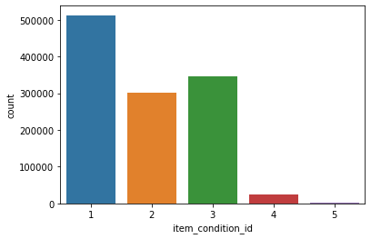

```python
sns.countplot(x='item_condition_id', data=X_train)
```

```python
X_train['item_condition_id'].value_counts(normalize=True)
```

```
1    0.431955
3    0.291504
2    0.253319
4    0.021602
5    0.001619
Name: item_condition_id, dtype: float64
```

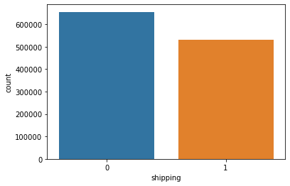

```python
sns.countplot(x='shipping', data=X_train)
```

```python
X_train['shipping'].value_counts(normalize=True)
```

```
0    0.552697
1    0.447303
Name: shipping, dtype: float64
```

Vidimo da je u vise slucajeva (55%) kupac odgovoran za pokrivanje troskova.

```python
print('Top 10 category names in train dataset')
display(X_train['category_name'].value_counts()[:10])
```

```
Top 10 category names in train dataset
```

```
Women/Athletic Apparel/Pants, Tights, Leggings                 48202
Women/Tops & Blouses/T-Shirts                                  37020
Beauty/Makeup/Face                                             27500
Beauty/Makeup/Lips                                             23879
Electronics/Video Games & Consoles/Games                       21273
Beauty/Makeup/Eyes                                             20341
Electronics/Cell Phones & Accessories/Cases, Covers & Skins    19698
Women/Underwear/Bras                                           16984
Women/Tops & Blouses/Blouse                                    16261
Women/Tops & Blouses/Tank, Cami                                16254
Name: category_name, dtype: int64
```

```python
print('Top 10 brand names in train dataset')
display(X_train['brand_name'].value_counts()[:10])
```

```
Top 10 brand names in train dataset
```

```
PINK                 43262
Nike                 43200
Victoria's Secret    38428
LuLaRoe              24764
Apple                13871
FOREVER 21           12167
Nintendo             12013
Lululemon            11702
Michael Kors         11098
American Eagle       10597
Name: brand_name, dtype: int64
```

```python
print('Top 10 names in train dataset')
display(X_train['name'].value_counts()[:10])
```

```
Top 10 names in train dataset
```

```
Bundle                  1805
Reserved                 369
Converse                 352
Dress                    336
BUNDLE                   332
Coach purse              325
Lularoe TC leggings      320
Romper                   281
American Eagle Jeans     274
Nike                     270
Name: name, dtype: int64
```

```python
print('Top 10 item descriptions in train dataset')
display(X_train['item_description'].value_counts()[:10])
```

```
Top 10 item descriptions in train dataset
```

```
No description yet     66148
New                     3309
Brand new               2448
Good condition           993
Great condition          940
Like new                 802
NWT                      663
Never worn               661
New with tags            502
Excellent condition      482
Name: item_description, dtype: int64
```

#### 2.2.3. Target variable distribution

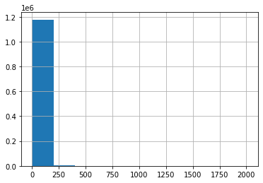

```python
y_train.hist(bins=10)
```

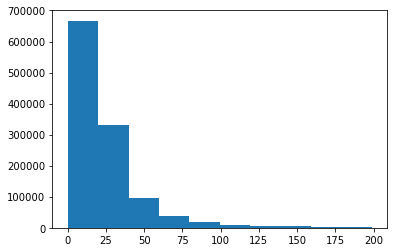

```python
plt.hist(y_train[y_train < 200], bins=10)
```

```python
y_train[y_train < 200].shape[0]/y_train.shape[0]
```

```
0.9926030414121758
```

```python
y_train[y_train >= 200].shape[0]/y_train.shape[0]
```

```
0.007396958587824233
```

```python
y_train[y_train >= 200].shape[0]
```

```
8773
```

Vidimo da imamo instance sa izuzetno visokim vrednostima, medjutim one nisu outlieri i necemo ih izbacivati. Dodatno, cak 99,3% varijabli imaju cenu kostanja manju od 200 novcanih jedinica.

#### 2.2.4. Corelation with target variable

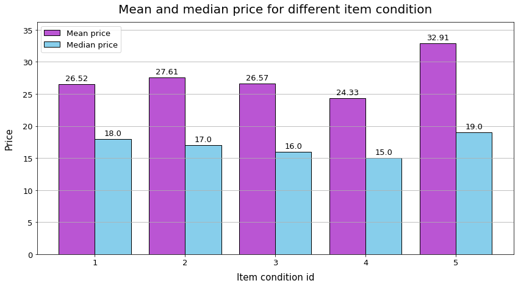

```python
fig, ax = plt.subplots(figsize=(14, 7))
x = np.arange(1, 6, 1)
y1 = X_train.join(y_train).groupby("item_condition_id")["price"].mean()
y2 = X_train.join(y_train).groupby("item_condition_id")["price"].median()

bars1 = ax.bar(x-0.2,
               y1,
               width=0.4, color="mediumorchid", label="Mean price", edgecolor="black")
bars2 = ax.bar(x+0.2,
               y2,
               width=0.4, color="skyblue", label="Median price", edgecolor="black")

ax.set_title("Mean and median price for different item condition", fontsize=20, pad=15)
ax.set_ylabel("Price", fontsize=15, labelpad=15)
ax.set_xlabel("Item condition id", fontsize=15, labelpad=10)
ax.tick_params(axis="x", labelsize=13)
ax.tick_params(axis="y", labelsize=13)
ax.bar_label(bars1, [str(round(x, 2)) for x in y1], padding=3, fontsize=13)
ax.bar_label(bars2, [str(round(x, 2)) for x in y2], padding=3, fontsize=13)
ax.grid(axis="y")
ax.margins(0.05, 0.1)
ax.legend(fontsize=13)
plt.show();
```

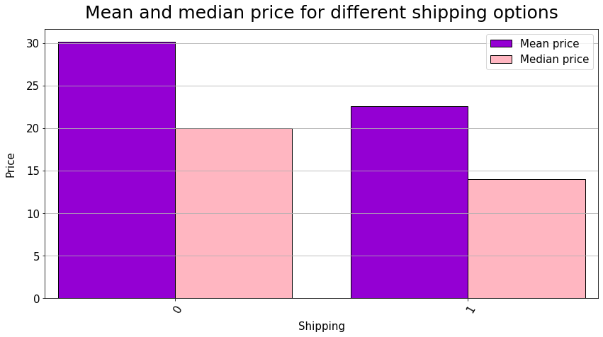

```python
fig, ax = plt.subplots(figsize=(14, 7))

shippings = X_train["shipping"].unique()
mean_prices = X_train.join(y_train).groupby("shipping")["price"].mean()
median_prices = X_train.join(y_train).groupby("shipping")["price"].median()
x = np.arange(0, len(shippings), 1)

bars1 = ax.bar(x-0.2,
               mean_prices.loc[shippings].values,
               width=0.4, color="darkviolet", label="Mean price", edgecolor="black")
bars2 = ax.bar(x+0.2,
               median_prices.loc[shippings].values,
               width=0.4, color="lightpink", label="Median price", edgecolor="black")

ax.set_title("Mean and median price for different shipping options", fontsize=25, pad=15)
ax.set_ylabel("Price", fontsize=15, labelpad=15)
ax.set_xlabel("Shipping", fontsize=15, labelpad=10)
ax.set_xticks(x)
ax.set_xticklabels(shippings, rotation = 60, ha="right", rotation_mode='anchor')
ax.tick_params(axis="x", labelsize=15)
ax.tick_params(axis="y", labelsize=15)
ax.grid(axis="y")
ax.margins(0.025, 0.05)
ax.legend(fontsize=15)
plt.show();
```

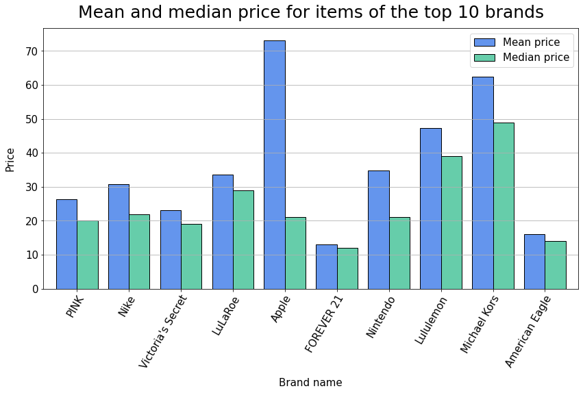

```python
fig, ax = plt.subplots(figsize=(14, 7))

brands = X_train["brand_name"].value_counts().index[:10]
mean_prices = X_train.join(y_train).groupby("brand_name")["price"].mean()
median_prices = X_train.join(y_train).groupby("brand_name")["price"].median()
x = np.arange(0, len(brands), 1)

bars1 = ax.bar(x-0.2,
               mean_prices.loc[brands].values,
               width=0.4, color="cornflowerblue", label="Mean price", edgecolor="black")
bars2 = ax.bar(x+0.2,
               median_prices.loc[brands].values,
               width=0.4, color="mediumaquamarine", label="Median price", edgecolor="black")

ax.set_title("Mean and median price for items of the top 10 brands", fontsize=25, pad=15)
ax.set_ylabel("Price", fontsize=15, labelpad=15)
ax.set_xlabel("Brand name", fontsize=15, labelpad=10)
ax.set_xticks(x)
ax.set_xticklabels(brands, rotation = 60, ha="right", rotation_mode='anchor')
ax.tick_params(axis="x", labelsize=15)
ax.tick_params(axis="y", labelsize=15)
ax.grid(axis="y")
ax.margins(0.025, 0.05)
ax.legend(fontsize=15)
plt.show();
```

[figure not shown]

```python
fig, ax = plt.subplots(figsize=(14, 7))

categories = X_train["category_name"].value_counts().index[:10]
mean_prices = X_train.join(y_train).groupby("category_name")["price"].mean()
median_prices = X_train.join(y_train).groupby("category_name")["price"].median()
x = np.arange(0, len(categories), 1)

bars1 = ax.bar(x-0.2,
               mean_prices.loc[categories].values,
               width=0.4, color="lightseagreen", label="Mean price", edgecolor="black")
bars2 = ax.bar(x+0.2,
               median_prices.loc[categories].values,
               width=0.4, color="deeppink", label="Median price", edgecolor="black")

ax.set_title("Mean and median price for items of the top 10 categories", fontsize=25, pad=15)
ax.set_ylabel("Price", fontsize=15, labelpad=15)
ax.set_xlabel("Category name", fontsize=15, labelpad=10)
ax.set_xticks(x)
ax.set_xticklabels(brands, rotation = 60, ha="right", rotation_mode='anchor')
ax.tick_params(axis="x", labelsize=15)
ax.tick_params(axis="y", labelsize=15)
ax.grid(axis="y")
ax.margins(0.025, 0.05)
ax.legend(fontsize=15)
plt.show();
```

# 3. Data Preparation

## 3.1. Dealing with missing values

```python
def dealing_with_missing_values(input_data):
    input_data.fillna({'item_description':'Unknown', 'brand_name':'Unknown',
                       'category_name':'Unknown/Unknown/Unknown'}, inplace=True)
    return input_data
```

```python
X_train = dealing_with_missing_values(X_train)
```

```python
X_train.isna().sum()
```

```
name                 0
item_condition_id    0
category_name        0
brand_name           0
shipping             0
item_description     0
dtype: int64
```

## 3.2. Feature Engenieering

### 3.2.1. Category_name

```python
split_categories = X_train['category_name'].str.split('/')

lengths = split_categories.apply(len)

print(lengths.max())
```

```
5
```

```python
lengths.value_counts()/lengths.shape[0]
```

```
3    0.997025
5    0.002090
4    0.000885
Name: category_name, dtype: float64
```

```python
def category_splitter(input_data):

    split_categories = input_data['category_name'].str.split('/', expand=True)

    input_data['category_1'] = split_categories[0]
    input_data['category_2'] = split_categories[1]
    input_data['category_3'] = split_categories[2]

    input_data.drop(columns=['category_name'], inplace=True)

    return input_data
```

```python
X_train=category_splitter(X_train)
```

```python
X_train.head()
```

|  | name | item_condition_id | brand_name | shipping | item_description | category_1 | category_2 | category_3 |
| --- | --- | --- | --- | --- | --- | --- | --- | --- |
| 604635 | Enzo | 3 | Unknown | 0 | Enzo Angiolini Mules/Clogs. Super Cute with so... | Women | Shoes | Mules & Clogs |
| 496799 | Black dress | 3 | Unknown | 1 | Xl long black dress Solid under with lace over... | Women | Dresses | Full-Length |
| 1035231 | 2 items for Brittany | 1 | Unknown | 0 | - Urban Decay Eyeshadow This has never been us... | Electronics | Cell Phones & Accessories | Cables & Adapters |
| 628659 | Texas budle | 2 | Unknown | 0 | Very cute!! No flaws | Women | Tops & Blouses | T-Shirts |
| 261459 | North face rain coat | 3 | The North Face | 0 | Sea foam green rain coat Size 18 XL in youth I... | Women | Athletic Apparel | Jackets |

```python
X_train['category_1'].value_counts()
```

```
Women                     531440
Beauty                    166506
Kids                      137363
Electronics                98119
Men                        74859
Home                       54163
Vintage & Collectibles     37227
Other                      36386
Handmade                   24722
Sports & Outdoors          20225
Unknown                     5018
Name: category_1, dtype: int64
```

```python
X_train['category_2'].value_counts()
```

```
Athletic Apparel             107552
Makeup                        99888
Tops & Blouses                85510
Shoes                         80391
Jewelry                       49310
Toys                          46575
Cell Phones & Accessories     42552
Women's Handbags              36683
Dresses                       36643
Women's Accessories           33893
Jeans                         28952
Video Games & Consoles        28777
Sweaters                      28528
Underwear                     26934
Skin Care                     23890
Home Décor                    20091
Fragrance                     19429
Kitchen & Dining              17473
Tops                          16415
Other                         15965
Swimwear                      15231
Men's Accessories             14882
Girls 2T-5T                   14776
Coats & Jackets               14697
Girls 0-24 Mos                14368
Boys 0-24 Mos                 12248
Girls (4+)                    12229
Boys (4+)                     11755
Boys 2T-5T                    11498
Tools & Accessories           10453
Media                          9254
Daily & Travel items           9140
Skirts                         8478
Office supplies                8438
Pants                          7434
TV, Audio & Surveillance       7258
Clothing                       6678
Sweats & Hoodies               6654
Accessories                    6608
Exercise                       6416
```

[output cut: 60 more lines]

```
Patterns                        153
Furniture                       137
Paper Ephemera                  132
Knitting                        128
Potty Training                  119
Woodworking                      95
Geekery                          87
Candles                          56
Suits                            53
Blazers & Sport Coats            53
Ceramics and Pottery             43
Dolls and Miniatures             40
Books and Zines                  37
Quilts                           28
Name: category_2, dtype: int64
```

```python
X_train['category_3'].value_counts()
```

```
Pants, Tights, Leggings                    48202
Face                                       40146
Other                                      40130
T-Shirts                                   37020
Shoes                                      25718
Games                                      24765
Lips                                       24624
Athletic                                   21636
Eyes                                       21008
Cases, Covers & Skins                      19698
Shorts                                     17501
Bras                                       16984
Blouse                                     16265
Tank, Cami                                 16254
Boots                                      16187
Above Knee, Mini                           16146
Necklaces                                  15872
Makeup Palettes                            15341
Women                                      15170
Shirts & Tops                              13508
Sandals                                    12315
Shoulder Bag                               12285
Fashion Sneakers                           12142
T-shirts                                   12037
Wallets                                    11928
Knee-Length                                11833
Tops & T-Shirts                            11646
Bracelets                                  11554
Slim, Skinny                               11405
Dolls & Accessories                        11159
Home Décor Accents                         10392
Two-Piece                                  10259
Action Figures & Statues                   10063
Earrings                                    9662
Hats                                        9629
One-Pieces                                  9351
Body                                        8642
Rings                                       8436
Hooded                                      8368
Accessories                                 8256
```

[output cut: 809 more lines]

```
Tiles                                          1
Non-Slip Bath Mats                             1
Crib Netting                                   1
Bathroom Furniture                             1
Draft Stoppers                                 1
Decorating                                     1
Women's Golf Clubs                             1
Carving                                        1
Four Button                                    1
Seat Covers                                    1
Videogame                                      1
Artist Bears                                   1
Towel                                          1
Cuff                                           1
Name: category_3, dtype: int64
```

Buduci da za category_3 vidimo da imamo 863 razlicitih reci, to ce nam biti previse za prebacivanje u numericke atribute, tako da necemo koristiti ovu kolonu za same modele, odnosno necemo je definisati u okviru pipeline-a.

```python
X_train.drop(columns=['category_3'], inplace=True)
```

```python
X_train.head()
```

|  | name | item_condition_id | brand_name | shipping | item_description | category_1 | category_2 |
| --- | --- | --- | --- | --- | --- | --- | --- |
| 604635 | Enzo | 3 | Unknown | 0 | Enzo Angiolini Mules/Clogs. Super Cute with so... | Women | Shoes |
| 496799 | Black dress | 3 | Unknown | 1 | Xl long black dress Solid under with lace over... | Women | Dresses |
| 1035231 | 2 items for Brittany | 1 | Unknown | 0 | - Urban Decay Eyeshadow This has never been us... | Electronics | Cell Phones & Accessories |
| 628659 | Texas budle | 2 | Unknown | 0 | Very cute!! No flaws | Women | Tops & Blouses |
| 261459 | North face rain coat | 3 | The North Face | 0 | Sea foam green rain coat Size 18 XL in youth I... | Women | Athletic Apparel |

```python
pd.set_option('display.max_rows', None)
pd.set_option('display.max_columns', None)
```

```python
X_train['category_2'].value_counts()
```

```
Athletic Apparel             107552
Makeup                        99888
Tops & Blouses                85510
Shoes                         80391
Jewelry                       49310
Toys                          46575
Cell Phones & Accessories     42552
Women's Handbags              36683
Dresses                       36643
Women's Accessories           33893
Jeans                         28952
Video Games & Consoles        28777
Sweaters                      28528
Underwear                     26934
Skin Care                     23890
Home Décor                    20091
Fragrance                     19429
Kitchen & Dining              17473
Tops                          16415
Other                         15965
Swimwear                      15231
Men's Accessories             14882
Girls 2T-5T                   14776
Coats & Jackets               14697
Girls 0-24 Mos                14368
Boys 0-24 Mos                 12248
Girls (4+)                    12229
Boys (4+)                     11755
Boys 2T-5T                    11498
Tools & Accessories           10453
Media                          9254
Daily & Travel items           9140
Skirts                         8478
Office supplies                8438
Pants                          7434
TV, Audio & Surveillance       7258
Clothing                       6678
Sweats & Hoodies               6654
Accessories                    6608
Exercise                       6416
```

[output cut: 60 more lines]

```
Patterns                        153
Furniture                       137
Paper Ephemera                  132
Knitting                        128
Potty Training                  119
Woodworking                      95
Geekery                          87
Candles                          56
Suits                            53
Blazers & Sport Coats            53
Ceramics and Pottery             43
Dolls and Miniatures             40
Books and Zines                  37
Quilts                           28
Name: category_2, dtype: int64
```

```python
X_train['category_2'].unique()
```

```
array(['Shoes', 'Dresses', 'Cell Phones & Accessories', 'Tops & Blouses',
       'Athletic Apparel', "Women's Handbags", 'Home Décor', 'Tops',
       'Computers & Tablets', 'Makeup', 'Cameras & Photography', 'Toys',
       'Sweats & Hoodies', 'Jewelry', 'Sweaters', "Men's Accessories",
       'Girls 2T-5T', 'Antique', 'Kitchen & Dining',
       "Women's Accessories", 'Video Games & Consoles', 'Underwear',
       'Fragrance', 'Bath & Body', 'Boys 0-24 Mos', 'Collectibles',
       'Bedding', 'Tools & Accessories', 'Swimwear', 'Pants',
       'Office supplies', 'Feeding', 'Jeans', 'Boys 2T-5T',
       'Coats & Jackets', 'Bath', 'Clothing', 'Accessories', 'Diapering',
       'Skin Care', 'Boys (4+)', 'Seasonal Décor', 'Automotive',
       'Apparel', 'Skirts', 'Paper Goods', 'Housewares', 'Other', 'Media',
       'Team Sports', 'Artwork', 'Girls 0-24 Mos', 'Bags and Purses',
       'Safety', 'Pet Supplies', 'Glass', 'Hair Care', 'Trading Cards',
       'Exercise', 'Daily & Travel items', 'Fan Shop', 'Supplies',
       'Storage & Organization', 'Weddings', 'Footwear', 'Holidays',
       'TV, Audio & Surveillance', 'Pregnancy & Maternity', 'Home Decor',
       'Books', 'Electronics', 'Bathing & Skin Care', 'Maternity', 'Toy',
       'Unknown', 'Home Appliances', 'Outdoors', 'Girls (4+)',
       'Cleaning Supplies', 'Woodworking', 'Shorts', 'Suits & Blazers',
       "Kids' Home Store", 'Children', 'Art', 'Geekery', 'Serving',
       'Musical instruments', 'Patterns', 'Gear',
       'Car Seats & Accessories', 'Book', 'Golf', 'Strollers', 'Nursery',
       'Magazines', 'Ceramics and Pottery', 'Crochet',
       'Car Audio, Video & GPS', 'Paper Ephemera', 'Others', 'Pets',
       'Potty Training', 'Music', 'Needlecraft', 'Furniture',
       'Health & Baby Care', 'Knitting', 'Candles', 'Suits',
       'Books and Zines', 'Quilts', 'Blazers & Sport Coats',
       'Dolls and Miniatures'], dtype=object)
```

```python
categories = X_train['category_2'].unique()

matching_pairs = {}

def clean_category(category):

    cleaned_category = category.replace('&', '')
    cleaned_category = cleaned_category.replace('and', '')

    words = cleaned_category.split()

    return words

for category in categories:

    words = clean_category(category)

    for other_category in categories:

        other_words = clean_category(other_category)

        if other_category == category or (other_category, category) in matching_pairs:
            continue

        if any(word in other_words for word in words):

            matching_pairs[(category, other_category)] = True

for pair in matching_pairs:
    print(pair)
```

```
('Cell Phones & Accessories', "Men's Accessories")
('Cell Phones & Accessories', "Women's Accessories")
('Cell Phones & Accessories', 'Tools & Accessories')
('Cell Phones & Accessories', 'Accessories')
('Cell Phones & Accessories', 'Car Seats & Accessories')
('Tops & Blouses', 'Tops')
('Athletic Apparel', 'Apparel')
("Women's Handbags", "Women's Accessories")
('Home Décor', 'Seasonal Décor')
('Home Décor', 'Home Decor')
('Home Décor', 'Home Appliances')
('Home Décor', "Kids' Home Store")
("Men's Accessories", "Women's Accessories")
("Men's Accessories", 'Tools & Accessories')
("Men's Accessories", 'Accessories')
("Men's Accessories", 'Car Seats & Accessories')
('Girls 2T-5T', 'Boys 2T-5T')
('Girls 2T-5T', 'Girls 0-24 Mos')
('Girls 2T-5T', 'Girls (4+)')
("Women's Accessories", 'Tools & Accessories')
("Women's Accessories", 'Accessories')
("Women's Accessories", 'Car Seats & Accessories')
('Video Games & Consoles', 'Car Audio, Video & GPS')
('Bath & Body', 'Bath')
('Boys 0-24 Mos', 'Boys 2T-5T')
('Boys 0-24 Mos', 'Boys (4+)')
('Boys 0-24 Mos', 'Girls 0-24 Mos')
('Tools & Accessories', 'Accessories')
('Tools & Accessories', 'Car Seats & Accessories')
('Boys 2T-5T', 'Boys (4+)')
('Coats & Jackets', 'Blazers & Sport Coats')
('Accessories', 'Car Seats & Accessories')
('Skin Care', 'Hair Care')
('Skin Care', 'Bathing & Skin Care')
('Skin Care', 'Health & Baby Care')
('Boys (4+)', 'Girls (4+)')
('Paper Goods', 'Paper Ephemera')
('Girls 0-24 Mos', 'Girls (4+)')
('Pet Supplies', 'Supplies')
('Pet Supplies', 'Cleaning Supplies')
('Hair Care', 'Bathing & Skin Care')
('Hair Care', 'Health & Baby Care')
('Supplies', 'Cleaning Supplies')
('Pregnancy & Maternity', 'Maternity')
('Home Decor', 'Home Appliances')
('Home Decor', "Kids' Home Store")
('Books', 'Books and Zines')
('Bathing & Skin Care', 'Health & Baby Care')
('Home Appliances', "Kids' Home Store")
('Suits & Blazers', 'Suits')
('Suits & Blazers', 'Blazers & Sport Coats')
('Car Seats & Accessories', 'Car Audio, Video & GPS')
```

- Toy + Toys
- Tops & Blouses + Tops
- Suits & Blazers + Blazers & Sport Coats + Suits
- Book + Books and Zines
- Home Decor + Home Décor
- Paper Goods + Paper Ephemera
- Sweats & Hoodies + Sweaters
- Shoes + Footwear
- Skin Care + Bathing & Skin Care
- Pregnancy & Maternity + Maternity

Vidimo da za kategoriju dva imamo dosta ponavljanja, te mozemo iste grupe grupisati kako bismo smanjili broj razlicitih mogucnosti, ali ipak zadrzali visok nivo granularnosti

```python
X_train[X_train['category_2']=='Pregnancy & Maternity']['category_2'].value_counts()
```

```
Pregnancy & Maternity    694
Name: category_2, dtype: int64
```

```python
X_train[X_train['category_2']=='Maternity']['category_2'].value_counts()
```

```
Maternity    2738
Name: category_2, dtype: int64
```

```python
def same_categories_mapping(input_data):
    input_data.loc[input_data['category_2'] == 'Tops', 'category_2'] = 'Tops & Blouses'
    input_data.loc[input_data['category_2'] == 'Toy', 'category_2'] = 'Toys'
    input_data.loc[input_data['category_2'] == 'Books and Zines', 'category_2'] = 'Book'
    input_data.loc[input_data['category_2'] == 'Home Decor', 'category_2'] = 'Home Décor'
    input_data.loc[input_data['category_2'] == 'Paper Ephemera', 'category_2'] = 'Paper Goods'
    input_data.loc[input_data['category_2'] == 'Sweats & Hoodies', 'category_2'] = 'Sweaters'
    input_data.loc[input_data['category_2'] == 'Footwear', 'category_2'] = 'Shoes'
    input_data.loc[input_data['category_2'] == 'Bathing & Skin Care', 'category_2'] = 'Skin Care'
    input_data.loc[input_data['category_2'] == 'Pregnancy & Maternity', 'category_2'] = 'Maternity'
    input_data.loc[(input_data['category_2'] == 'Suits') |
                   (input_data['category_2'] == 'Blazers & Sport Coats'), 'category_2'] = 'Suits & Blazers'
    input_data.loc[(input_data['category_2'] == '') |
                   (input_data['category_2'] == 'Blazers & Sport Coats'), 'category_2'] = 'Suits & Blazers'

    return input_data
```

```python
pd.set_option('display.max_rows', 60)  # Default value
pd.set_option('display.max_columns', 20)  # Default value
```

```python
pd.set_option('display.max_rows', None)
pd.set_option('display.max_columns', None)
```

```python
X_train=same_categories_mapping(X_train)
```

```python
print('Top 40 category_2 in train dataset')
display(X_train['category_2'].value_counts()[:40])
```

```
Top 40 category_2 in train dataset
```

```
Athletic Apparel             107552
Tops & Blouses               101925
Makeup                        99888
Shoes                         80804
Toys                          52439
Jewelry                       49310
Cell Phones & Accessories     42552
Women's Handbags              36683
Dresses                       36643
Sweaters                      35182
Women's Accessories           33893
Jeans                         28952
Video Games & Consoles        28777
Underwear                     26934
Skin Care                     24483
Home Décor                    20488
Fragrance                     19429
Kitchen & Dining              17473
Other                         15965
Swimwear                      15231
Men's Accessories             14882
Girls 2T-5T                   14776
Coats & Jackets               14697
Girls 0-24 Mos                14368
Boys 0-24 Mos                 12248
Girls (4+)                    12229
Boys (4+)                     11755
Boys 2T-5T                    11498
Tools & Accessories           10453
Media                          9254
Daily & Travel items           9140
Skirts                         8478
Office supplies                8438
Pants                          7434
TV, Audio & Surveillance       7258
Clothing                       6678
Accessories                    6608
Exercise                       6416
Books                          6269
Hair Care                      6240
Name: category_2, dtype: int64
```

```python
X_train['category_2'].value_counts()[:40].sum()/X_train['category_2'].shape[0]
```

```
0.9053091495310397
```

Zadrzavanjem 40% kategorija zadrzavamo 90.5% varijabiliteta.

```python
top_categories = X_train['category_2'].value_counts()[:40].index.tolist()

X_train.loc[~X_train['category_2'].isin(top_categories), 'category_2'] = 'Unknown'
```

```python
X_train['category_2'].value_counts(normalize=True)*100
```

```
Unknown                      9.469085
Athletic Apparel             9.068251
Tops & Blouses               8.593811
Makeup                       8.422061
Shoes                        6.812993
Toys                         4.421396
Jewelry                      4.157575
Cell Phones & Accessories    3.587774
Women's Handbags             3.092929
Dresses                      3.089556
Sweaters                     2.966372
Women's Accessories          2.857690
Jeans                        2.441089
Video Games & Consoles       2.426334
Underwear                    2.270941
Skin Care                    2.064285
Home Décor                   1.727447
Fragrance                    1.638157
Kitchen & Dining             1.473237
Other                        1.346090
Swimwear                     1.284202
Men's Accessories            1.254776
Girls 2T-5T                  1.245839
Coats & Jackets              1.239178
Girls 0-24 Mos               1.211439
Boys 0-24 Mos                1.032691
Girls (4+)                   1.031089
Boys (4+)                    0.991123
Boys 2T-5T                   0.969454
Tools & Accessories          0.881345
Media                        0.780251
Daily & Travel items         0.770639
Skirts                       0.714823
Office supplies              0.711450
Pants                        0.626798
TV, Audio & Surveillance     0.611959
Clothing                     0.563056
Accessories                  0.557154
Exercise                     0.540965
Books                        0.528571
Hair Care                    0.526126
Name: category_2, dtype: float64
```

```python
X_train.head()
```

|  | name | item_condition_id | brand_name | shipping | item_description | category_1 | category_2 |
| --- | --- | --- | --- | --- | --- | --- | --- |
| 604635 | Enzo | 3 | Unknown | 0 | Enzo Angiolini Mules/Clogs. Super Cute with so... | Women | Shoes |
| 496799 | Black dress | 3 | Unknown | 1 | Xl long black dress Solid under with lace over... | Women | Dresses |
| 1035231 | 2 items for Brittany | 1 | Unknown | 0 | - Urban Decay Eyeshadow This has never been us... | Electronics | Cell Phones & Accessories |
| 628659 | Texas budle | 2 | Unknown | 0 | Very cute!! No flaws | Women | Tops & Blouses |
| 261459 | North face rain coat | 3 | The North Face | 0 | Sea foam green rain coat Size 18 XL in youth I... | Women | Athletic Apparel |

### 3.2.2. Brand name

```python
X_train['brand_name'].value_counts(normalize=True)*100
```

```
Unknown                                    42.656160
PINK                                        3.647637
Nike                                        3.642410
Victoria's Secret                           3.240058
LuLaRoe                                     2.087978
Apple                                       1.169534
FOREVER 21                                  1.025861
Nintendo                                    1.012877
Lululemon                                   0.986655
Michael Kors                                0.935728
American Eagle                              0.893486
Rae Dunn                                    0.827046
Sephora                                     0.823674
Coach                                       0.704199
Bath & Body Works                           0.699140
Disney                                      0.696695
Adidas                                      0.686493
Funko                                       0.625618
Under Armour                                0.567019
Sony                                        0.536918
Old Navy                                    0.513226
Hollister                                   0.470900
Carter's                                    0.429754
Urban Decay                                 0.418371
The North Face                              0.416010
Independent                                 0.399991
Too Faced                                   0.391812
Xbox                                        0.386416
Brandy Melville                             0.382537
Kate Spade                                  0.367276
MAC                                         0.360784
Gap                                         0.345945
Kendra Scott                                0.344258
Tarte                                       0.334141
UGG Australia                               0.312387
Polo Ralph Lauren                           0.308677
VANS                                        0.307666
Charlotte Russe                             0.283973
Vera Bradley                                0.274277
SeneGence                                   0.272338
```

[output cut: 4506 more lines]

```
Home-it                                     0.000084
Peruvian Connection                         0.000084
K&N Engineering                             0.000084
Custo Barcelona                             0.000084
Avanti                                      0.000084
Joan & David                                0.000084
Antik Batik                                 0.000084
Atlantis Toy and Hobby                      0.000084
Allen Solly                                 0.000084
Breckenridge                                0.000084
David & Goliath                             0.000084
Huggies Little Swimmers                     0.000084
Butterfly                                   0.000084
Shenanigans                                 0.000084
Name: brand_name, dtype: float64
```

```python
X_train['brand_name'].value_counts()
```

```
Unknown                                    505914
PINK                                        43262
Nike                                        43200
Victoria's Secret                           38428
LuLaRoe                                     24764
Apple                                       13871
FOREVER 21                                  12167
Nintendo                                    12013
Lululemon                                   11702
Michael Kors                                11098
American Eagle                              10597
Rae Dunn                                     9809
Sephora                                      9769
Coach                                        8352
Bath & Body Works                            8292
Disney                                       8263
Adidas                                       8142
Funko                                        7420
Under Armour                                 6725
Sony                                         6368
Old Navy                                     6087
Hollister                                    5585
Carter's                                     5097
Urban Decay                                  4962
The North Face                               4934
Independent                                  4744
Too Faced                                    4647
Xbox                                         4583
Brandy Melville                              4537
Kate Spade                                   4356
MAC                                          4279
Gap                                          4103
Kendra Scott                                 4083
Tarte                                        3963
UGG Australia                                3705
Polo Ralph Lauren                            3661
VANS                                         3649
Charlotte Russe                              3368
Vera Bradley                                 3253
SeneGence                                    3230
```

[output cut: 4506 more lines]

```
Home-it                                         1
Peruvian Connection                             1
K&N Engineering                                 1
Custo Barcelona                                 1
Avanti                                          1
Joan & David                                    1
Antik Batik                                     1
Atlantis Toy and Hobby                          1
Allen Solly                                     1
Breckenridge                                    1
David & Goliath                                 1
Huggies Little Swimmers                         1
Butterfly                                       1
Shenanigans                                     1
Name: brand_name, dtype: int64
```

```python
non_unknown_brand = X_train[X_train['brand_name'] != 'Unknown']
```

```python
non_unknown_brand.shape
```

```
(680114, 7)
```

```python
non_unknown_brand['brand_name'].value_counts()[:30]
```

```
PINK                 43262
Nike                 43200
Victoria's Secret    38428
LuLaRoe              24764
Apple                13871
FOREVER 21           12167
Nintendo             12013
Lululemon            11702
Michael Kors         11098
American Eagle       10597
Rae Dunn              9809
Sephora               9769
Coach                 8352
Bath & Body Works     8292
Disney                8263
Adidas                8142
Funko                 7420
Under Armour          6725
Sony                  6368
Old Navy              6087
Hollister             5585
Carter's              5097
Urban Decay           4962
The North Face        4934
Independent           4744
Too Faced             4647
Xbox                  4583
Brandy Melville       4537
Kate Spade            4356
MAC                   4279
Name: brand_name, dtype: int64
```

```python
non_unknown_brand['brand_name'].value_counts()[:10].sum()/non_unknown_brand['brand_name'].shape[0]
```

```
0.3250954986958069
```

```python
non_unknown_brand['brand_name'].value_counts()[:10].sum()/X_train['brand_name'].shape[0]
```

```
0.1864222429824591
```

Mozemo dakle ili

- napraviti binarnu promenljivu ima ili nema brend poznat kupcu
- ili izabrati top 30 brendova

Dodatno, mozemo primetiti da su uglavnom jako poznati tj luksuzniji brednovi ti koji su zastupljeni na listi top 30, što ukazuje da samo postojanje brenda nosi sa sobom uglavnom višu cenu, pa nam binarna varijabla može biti u ovom slučaju i te kako korisna.

```python
X_train['brand_flag'] = X_train['brand_name'].apply(lambda x: 0 if x == 'Unknown' else 1)
```

```python
X_train.head()
```

|  | name | item_condition_id | brand_name | shipping | item_description | category_1 | category_2 | brand_flag |
| --- | --- | --- | --- | --- | --- | --- | --- | --- |
| 604635 | Enzo | 3 | Unknown | 0 | Enzo Angiolini Mules/Clogs. Super Cute with so... | Women | Shoes | 0 |
| 496799 | Black dress | 3 | Unknown | 1 | Xl long black dress Solid under with lace over... | Women | Dresses | 0 |
| 1035231 | 2 items for Brittany | 1 | Unknown | 0 | - Urban Decay Eyeshadow This has never been us... | Electronics | Cell Phones & Accessories | 0 |
| 628659 | Texas budle | 2 | Unknown | 0 | Very cute!! No flaws | Women | Tops & Blouses | 0 |
| 261459 | North face rain coat | 3 | The North Face | 0 | Sea foam green rain coat Size 18 XL in youth I... | Women | Athletic Apparel | 1 |

```python
X_train.info()
```

```
<class 'pandas.core.frame.DataFrame'>
Int64Index: 1186028 entries, 604635 to 305711
Data columns (total 8 columns):
 #   Column             Non-Null Count    Dtype
---  ------             --------------    -----
 0   name               1186028 non-null  object
 1   item_condition_id  1186028 non-null  int64
 2   brand_name         1186028 non-null  object
 3   shipping           1186028 non-null  int64
 4   item_description   1186028 non-null  object
 5   category_1         1186028 non-null  object
 6   category_2         1186028 non-null  object
 7   brand_flag         1186028 non-null  int64
dtypes: int64(3), object(5)
memory usage: 113.7+ MB
```

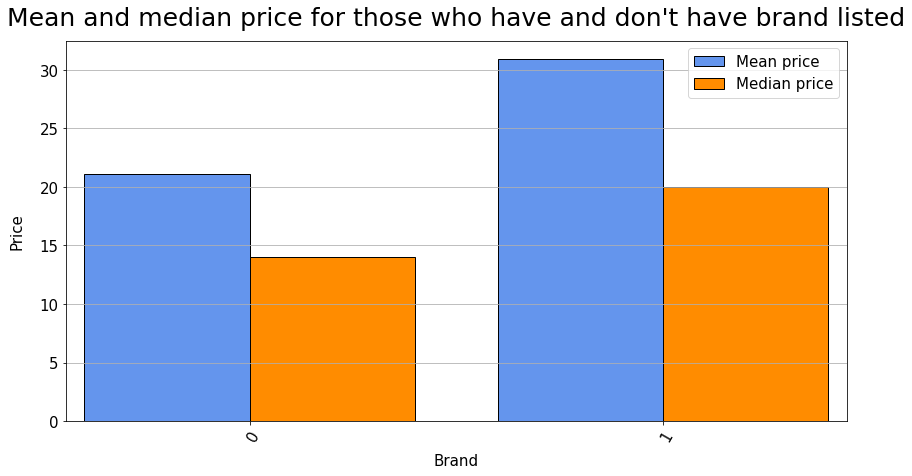

```python
fig, ax = plt.subplots(figsize=(14, 7))

shippings = X_train["brand_flag"].unique()
mean_prices = X_train.join(y_train).groupby("brand_flag")["price"].mean()
median_prices = X_train.join(y_train).groupby("brand_flag")["price"].median()
x = np.arange(0, len(shippings), 1)

bars1 = ax.bar(x-0.2,
               mean_prices.loc[shippings].values,
               width=0.4, color="cornflowerblue", label="Mean price", edgecolor="black")
bars2 = ax.bar(x+0.2,
               median_prices.loc[shippings].values,
               width=0.4, color="darkorange", label="Median price", edgecolor="black")

ax.set_title("Mean and median price for those who have and don't have brand listed", fontsize=25, pad=15)
ax.set_ylabel("Price", fontsize=15, labelpad=15)
ax.set_xlabel("Brand", fontsize=15, labelpad=10)
ax.set_xticks(x)
ax.set_xticklabels(shippings, rotation = 60, ha="right", rotation_mode='anchor')
ax.tick_params(axis="x", labelsize=15)
ax.tick_params(axis="y", labelsize=15)
ax.grid(axis="y")
ax.margins(0.025, 0.05)
ax.legend(fontsize=15)
plt.show();
```

```python
X_train.join(y_train).groupby("brand_flag")["price"].quantile([0.1,0.2,0.25,0.3,0.4,0.5,0.6,0.7,0.75,0.8,0.9,0.95,1])
```

```
brand_flag
0           0.10       6.0
            0.20       8.0
            0.25       9.0
            0.30      10.0
            0.40      12.0
            0.50      14.0
            0.60      17.0
            0.70      21.0
            0.75      24.0
            0.80      27.0
            0.90      40.0
            0.95      56.0
            1.00    2000.0
1           0.10       9.0
            0.20      11.0
            0.25      12.0
            0.30      14.0
            0.40      16.0
            0.50      20.0
            0.60      24.0
            0.70      30.0
            0.75      34.0
            0.80      39.0
            0.90      60.0
            0.95      86.0
            1.00    2009.0
Name: price, dtype: float64
```

Kao sto je bilo i ocekivano, razlike su uocljive i postojanje brenda sa sobom nosi visu cenu.

Ipak, kako bismo dodali jos dodatnih 18% varijabiliteta i pomogli modelu, napravicemo novi atribut koji ce sadrzati vrednosti samo najzastupljenijih brendova (onih preko 10.000 instanci na trening skupu), dakle izabracemo top 10 brendova.

```python
top_brands = X_train['brand_name'].value_counts()[:11].index.tolist()

X_train.loc[~X_train['brand_name'].isin(top_brands), 'brand_name'] = 'Unknown'
```

```python
X_train['brand_name'].value_counts()
```

```
Unknown              964926
PINK                  43262
Nike                  43200
Victoria's Secret     38428
LuLaRoe               24764
Apple                 13871
FOREVER 21            12167
Nintendo              12013
Lululemon             11702
Michael Kors          11098
American Eagle        10597
Name: brand_name, dtype: int64
```

### 3.2.3. name i item description

```python
print('Top 10 item descriptions in train dataset')
display(X_train['item_description'].value_counts(normalize=True)[:10]*100)
```

```
Top 10 item descriptions in train dataset
```

```
No description yet     5.577271
New                    0.278998
Brand new              0.206403
Good condition         0.083725
Great condition        0.079256
Like new               0.067621
NWT                    0.055901
Never worn             0.055732
New with tags          0.042326
Excellent condition    0.040640
Name: item_description, dtype: float64
```

Za kolonu item description cemo tamo gde nema vrednost upisati kolonu name, i to zbog:

- 1. item_description kolona informativnija od same name kolone, ali u nedostatku iste i name ce nam biti informativan (name je uglavnom skracena verzija item description kada oba postoje)
- 1. name nema missing values
- 1. cak 5% trening skupa nemamo description (No description yet), a to je najzastupljenija kategorija
- 1. a i da smo za tu kolonu upisivali Unknown gde nam je vrednost bila NaN.

```python
X_train.loc[X_train['item_description'] == 'Unknown' , 'item_description'] = 'No description yet'
```

```python
print('Top 10 item descriptions in train dataset')
display(X_train['item_description'].value_counts(normalize=True)[:10]*100)
```

```
Top 10 item descriptions in train dataset
```

```
No description yet     5.577609
New                    0.278998
Brand new              0.206403
Good condition         0.083725
Great condition        0.079256
Like new               0.067621
NWT                    0.055901
Never worn             0.055732
New with tags          0.042326
Excellent condition    0.040640
Name: item_description, dtype: float64
```

```python
X_train.loc[X_train['item_description'] == 'No description yet', 'item_description'] = X_train['name']
```

```python
X_train.head()
```

|  | name | item_condition_id | brand_name | shipping | item_description | category_1 | category_2 | brand_flag |
| --- | --- | --- | --- | --- | --- | --- | --- | --- |
| 604635 | Enzo | 3 | Unknown | 0 | Enzo Angiolini Mules/Clogs. Super Cute with so... | Women | Shoes | 0 |
| 496799 | Black dress | 3 | Unknown | 1 | Xl long black dress Solid under with lace over... | Women | Dresses | 0 |
| 1035231 | 2 items for Brittany | 1 | Unknown | 0 | - Urban Decay Eyeshadow This has never been us... | Electronics | Cell Phones & Accessories | 0 |
| 628659 | Texas budle | 2 | Unknown | 0 | Very cute!! No flaws | Women | Tops & Blouses | 0 |
| 261459 | North face rain coat | 3 | Unknown | 0 | Sea foam green rain coat Size 18 XL in youth I... | Women | Athletic Apparel | 1 |

```python
print('Top 10 item descriptions in train dataset')
display(X_train['item_description'].value_counts(normalize=True)[:10]*100)
```

```
Top 10 item descriptions in train dataset
```

```
New                    0.279167
Brand new              0.206572
Good condition         0.083893
Great condition        0.079256
Like new               0.067874
NWT                    0.055901
Never worn             0.055901
New with tags          0.042410
Bundle                 0.041314
Excellent condition    0.040640
Name: item_description, dtype: float64
```

```python
X_train.drop(columns=['name'], inplace=True)
```

```python
X_train.head()
```

|  | item_condition_id | brand_name | shipping | item_description | category_1 | category_2 | brand_flag |
| --- | --- | --- | --- | --- | --- | --- | --- |
| 604635 | 3 | Unknown | 0 | Enzo Angiolini Mules/Clogs. Super Cute with so... | Women | Shoes | 0 |
| 496799 | 3 | Unknown | 1 | Xl long black dress Solid under with lace over... | Women | Dresses | 0 |
| 1035231 | 1 | Unknown | 0 | - Urban Decay Eyeshadow This has never been us... | Electronics | Cell Phones & Accessories | 0 |
| 628659 | 2 | Unknown | 0 | Very cute!! No flaws | Women | Tops & Blouses | 0 |
| 261459 | 3 | Unknown | 0 | Sea foam green rain coat Size 18 XL in youth I... | Women | Athletic Apparel | 1 |

### 3.2.4. item description (NLP)

```python
print('Top 20 item descriptions in train dataset')
display(X_train['item_description'].value_counts(normalize=True)[:20]*100)
```

```
Top 20 item descriptions in train dataset
```

```
New                    0.279167
Brand new              0.206572
Good condition         0.083893
Great condition        0.079256
Like new               0.067874
NWT                    0.055901
Never worn             0.055901
New with tags          0.042410
Bundle                 0.041314
Excellent condition    0.040640
Never used             0.039544
Worn once              0.037520
Brand new with tags    0.036340
Size small             0.031618
Brand new!             0.030606
New in box             0.029257
BNWT                   0.029004
Reserved               0.028836
Brand New              0.027487
Brand new.             0.026053
Name: item_description, dtype: float64
```

```python
def remove_emoji(sentence):
    pattern = re.compile("["
                           u"\U0001F600-\U0001F64F"
                           u"\U0001F300-\U0001F5FF"
                           u"\U0001F680-\U0001F6FF"
                           u"\U0001F1E0-\U0001F1FF"
                           u"\U00002702-\U000027B0"
                           u"\U000024C2-\U0001F251"
                           "]+", flags=re.UNICODE)
    return pattern.sub(r'', sentence)
```

```python
def remove_punctuation(sentence):
    regular_punct = list(string.punctuation)
    for punc in regular_punct:
        if punc in sentence:
            sentence = sentence.replace(punc, ' ')
    return sentence.strip()
```

```python
porter_stemmer = PorterStemmer()
def stemming(text):
    input_str=word_tokenize(text)
    res = [porter_stemmer.stem(word) for word in input_str]
    return ' '.join(res)
```

```python
words_to_exclude = ['i', 'me', 'my', 'myself', 'we', 'our', 'ours', 'ourselves', 'you', "you're", "you've",\
            "you'll", "you'd", 'your', 'yours', 'yourself', 'yourselves', 'he', 'him', 'his', 'himself', \
            'she', "she's", 'her', 'hers', 'herself', 'it', "it's", 'its', 'itself', 'they', 'them', 'their',\
            'theirs', 'themselves', 'what', 'which', 'who', 'whom', 'this', 'that', "that'll", 'these', 'those', \
            'am', 'is', 'are', 'was', 'were', 'be', 'been', 'being', 'have', 'has', 'had', 'having', 'do', 'does', \
            'did', 'doing', 'a', 'an', 'the', 'and', 'but', 'if', 'or', 'because', 'as', 'until', 'while', 'of', \
            'at', 'by', 'for', 'with', 'about', 'against', 'between', 'into', 'through', 'during', 'before', 'after',\
            'above', 'below', 'to', 'from', 'up', 'down', 'in', 'out', 'on', 'off', 'over', 'under', 'again', 'further',\
            'then', 'once', 'here', 'there', 'when', 'where', 'why', 'how', 'all', 'any', 'both', 'each', 'few', 'more',\
            'most', 'other', 'some', 'such', 'only', 'own', 'same', 'so', 'than', 'too', 'very', \
            's', 't', 'can', 'will', 'just', 'don', "don't", 'should', "should've", 'now', 'd', 'll', 'm', 'o', 're', \
            've', 'y', 'ain', 'aren', "aren't", 'couldn', "couldn't", 'didn', "didn't", 'doesn', "doesn't", 'hadn',\
            "hadn't", 'hasn', "hasn't", 'haven', "haven't", 'isn', "isn't", 'ma', 'mightn', "mightn't", 'mustn',\
            "mustn't", 'needn', "needn't", 'shan', "shan't", 'shouldn', "shouldn't", 'wasn', "wasn't", 'weren', "weren't", \
            'won', "won't", 'wouldn', "wouldn't"]
```

```python
X_train.head()
```

|  | item_condition_id | brand_name | shipping | item_description | category_1 | category_2 | brand_flag |
| --- | --- | --- | --- | --- | --- | --- | --- |
| 604635 | 3 | Unknown | 0 | Enzo Angiolini Mules/Clogs. Super Cute with so... | Women | Shoes | 0 |
| 496799 | 3 | Unknown | 1 | Xl long black dress Solid under with lace over... | Women | Dresses | 0 |
| 1035231 | 1 | Unknown | 0 | - Urban Decay Eyeshadow This has never been us... | Electronics | Cell Phones & Accessories | 0 |
| 628659 | 2 | Unknown | 0 | Very cute!! No flaws | Women | Tops & Blouses | 0 |
| 261459 | 3 | Unknown | 0 | Sea foam green rain coat Size 18 XL in youth I... | Women | Athletic Apparel | 1 |

```python
def process_text(input_data, col):
    processed_data = []
    for sentence in input_data[col].values:
            sent = sentence
            sent = sent.replace('\\r', ' ') #sklanja escape karakter, prelazak kursova ali ne u novi red
            sent = sent.replace('\\"', ' ') #sklanja dvosturke navodnike
            sent = sent.replace('\\n', ' ') #sklanja enter
            sent = re.sub('[^A-Za-z]+', ' ', sent) #sklanja sva slova koja nisu alfabet tj engleska abeceda
            sent = remove_emoji(sent)
            sent = remove_punctuation(sent)
            sent = ' '.join(e for e in sent.split() if e not in words_to_exclude)
            sent = stemming(sent)
            processed_data.append(sent.lower().strip())
    input_data[col] = processed_data
    return input_data
```

```python
X_train.head()
```

|  | item_condition_id | brand_name | shipping | item_description | category_1 | category_2 | brand_flag |
| --- | --- | --- | --- | --- | --- | --- | --- |
| 604635 | 3 | Unknown | 0 | Enzo Angiolini Mules/Clogs. Super Cute with so... | Women | Shoes | 0 |
| 496799 | 3 | Unknown | 1 | Xl long black dress Solid under with lace over... | Women | Dresses | 0 |
| 1035231 | 1 | Unknown | 0 | - Urban Decay Eyeshadow This has never been us... | Electronics | Cell Phones & Accessories | 0 |
| 628659 | 2 | Unknown | 0 | Very cute!! No flaws | Women | Tops & Blouses | 0 |
| 261459 | 3 | Unknown | 0 | Sea foam green rain coat Size 18 XL in youth I... | Women | Athletic Apparel | 1 |

```python
X_train_proba=pd.DataFrame()
```

```python
X_train_proba = process_text(X_train, 'item_description')
```

```python
X_train_proba.head()
```

|  | item_condition_id | brand_name | shipping | item_description | category_1 | category_2 | brand_flag |
| --- | --- | --- | --- | --- | --- | --- | --- |
| 604635 | 3 | Unknown | 0 | enzo angiolini mule clog super cute soft black... | Women | Shoes | 0 |
| 496799 | 3 | Unknown | 1 | xl long black dress solid lace no true sign we... | Women | Dresses | 0 |
| 1035231 | 1 | Unknown | 0 | urban decay eyeshadow thi never use look littl... | Electronics | Cell Phones & Accessories | 0 |
| 628659 | 2 | Unknown | 0 | veri cute no flaw | Women | Tops & Blouses | 0 |
| 261459 | 3 | Unknown | 0 | sea foam green rain coat size xl youth i usual... | Women | Athletic Apparel | 1 |

```python
X_train_proba.to_csv(r'D:\USERS\Andjela\Downloads\project_data\X_train_proba.csv', index=False)
```

```python
X_train_2=X_train_proba.copy()
```

```python
X_train_2.head()
```

|  | item_condition_id | brand_name | shipping | item_description | category_1 | category_2 | brand_flag |
| --- | --- | --- | --- | --- | --- | --- | --- |
| 604635 | 3 | Unknown | 0 | enzo angiolini mule clog super cute soft black... | Women | Shoes | 0 |
| 496799 | 3 | Unknown | 1 | xl long black dress solid lace no true sign we... | Women | Dresses | 0 |
| 1035231 | 1 | Unknown | 0 | urban decay eyeshadow thi never use look littl... | Electronics | Cell Phones & Accessories | 0 |
| 628659 | 2 | Unknown | 0 | veri cute no flaw | Women | Tops & Blouses | 0 |
| 261459 | 3 | Unknown | 0 | sea foam green rain coat size xl youth i usual... | Women | Athletic Apparel | 1 |

```python
def get_text_encodings(input_data, col_name, min_val, max_val):
    vect_tr = CountVectorizer(ngram_range=(min_val, max_val), max_features=10, min_df=250000)
    vect_tr.fit(input_data[col_name])

    input_data_encoded = pd.DataFrame(vect_tr.transform(input_data[col_name]).todense(),
                                      columns=vect_tr.get_feature_names_out())

    input_data_encoded.index = input_data.index

    return input_data_encoded
```

```python
X_train_2 = get_text_encodings(X_train_2,'item_description', 1, 1)
```

```python
X_train_2.head()
```

|  | new | size |
| --- | --- | --- |
| 604635 | 0 | 2 |
| 496799 | 0 | 0 |
| 1035231 | 1 | 0 |
| 628659 | 0 | 0 |
| 261459 | 0 | 1 |

Vidimo da se na trening setu sa minimalnim pojavljivanjem od 250.000 reci pojavljuju dve najcesce upotrebljene reci a to su new i size, buduci da ce nam ove informacije znaciti za samo modelovanje, u pipeline-u cemo definisati flag-ove za ove dve kljucne reci.

```python
X_train_2['new'].value_counts()
```

```
0     816088
1     343389
2      22415
3       3199
4        639
5        171
6         58
7         29
8         15
9         11
10         6
11         3
12         2
14         1
13         1
15         1
Name: new, dtype: int64
```

```python
X_train_2.info()
```

```
<class 'pandas.core.frame.DataFrame'>
Int64Index: 1186028 entries, 604635 to 305711
Data columns (total 2 columns):
 #   Column  Non-Null Count    Dtype
---  ------  --------------    -----
 0   new     1186028 non-null  int64
 1   size    1186028 non-null  int64
dtypes: int64(2)
memory usage: 59.4 MB
```

```python
X_train.info()
```

[output not shown]

```python
X_train.head()
```

[output not shown]

```python
X_train['size_flag']=X_train_2['size'].apply(lambda x: 0 if x == 0 else 1)
```

```python
X_train['new_flag']=X_train_2['new'].apply(lambda x: 0 if x == 0 else 1)
```

```python
X_train.head()
```

|  | item_condition_id | brand_name | shipping | item_description | category_1 | category_2 | brand_flag | size_flag | new_flag |
| --- | --- | --- | --- | --- | --- | --- | --- | --- | --- |
| 604635 | 3 | Unknown | 0 | enzo angiolini mule clog super cute soft black... | Women | Shoes | 0 | 1 | 0 |
| 496799 | 3 | Unknown | 1 | xl long black dress solid lace no true sign we... | Women | Dresses | 0 | 0 | 0 |
| 1035231 | 1 | Unknown | 0 | urban decay eyeshadow thi never use look littl... | Electronics | Cell Phones & Accessories | 0 | 0 | 1 |
| 628659 | 2 | Unknown | 0 | veri cute no flaw | Women | Tops & Blouses | 0 | 0 | 0 |
| 261459 | 3 | Unknown | 0 | sea foam green rain coat size xl youth i usual... | Women | Athletic Apparel | 1 | 1 | 0 |

```python
X_train.info()
```

```
<class 'pandas.core.frame.DataFrame'>
Int64Index: 1186028 entries, 604635 to 305711
Data columns (total 9 columns):
 #   Column             Non-Null Count    Dtype
---  ------             --------------    -----
 0   item_condition_id  1186028 non-null  int64
 1   brand_name         1186028 non-null  object
 2   shipping           1186028 non-null  int64
 3   item_description   1186028 non-null  object
 4   category_1         1186028 non-null  object
 5   category_2         1186028 non-null  object
 6   brand_flag         1186028 non-null  int64
 7   size_flag          1186028 non-null  int64
 8   new_flag           1186028 non-null  int64
dtypes: int64(5), object(4)
memory usage: 122.7+ MB
```

```python
X_train.drop(columns=['item_description'], inplace=True)
```

```python
X_train.head()
```

|  | item_condition_id | brand_name | shipping | category_1 | category_2 | brand_flag | size_flag | new_flag |
| --- | --- | --- | --- | --- | --- | --- | --- | --- |
| 604635 | 3 | Unknown | 0 | Women | Shoes | 0 | 1 | 0 |
| 496799 | 3 | Unknown | 1 | Women | Dresses | 0 | 0 | 0 |
| 1035231 | 1 | Unknown | 0 | Electronics | Cell Phones & Accessories | 0 | 0 | 1 |
| 628659 | 2 | Unknown | 0 | Women | Tops & Blouses | 0 | 0 | 0 |
| 261459 | 3 | Unknown | 0 | Women | Athletic Apparel | 1 | 1 | 0 |

- model (cross val, hiperparemetri, RMSE)

# 4. Pipeline - Complete Process

Kako bismo ceo proces lakse ispratili celokupan proces postavicemo pipeline. Iskoristicemo kodove koje smo gore definisali za same funkcije.

```python
file_path = r'D:\USERS\Andjela\Downloads\project_data\train.tsv'
train=pd.read_csv(file_path, sep='\t')
```

```python
X = train.drop(columns='price')
X.drop(columns=['train_id'], inplace=True)
y = train['price']
del train
```

```python
X_train, X_test, y1_train, y1_test = train_test_split(X, y, test_size=0.2, random_state=0)
```

```python
y_train=np.log1p(y1_train)
```

```python
y_test=np.log1p(y1_test)
```

## 4.1. Pipeline for data cleaning

```python
from sklearn.base import BaseEstimator, TransformerMixin

class MissingValuesHandler(BaseEstimator, TransformerMixin):
    def fit(self, X, y=None):
        return self

    def transform(self, X):
        print('1 - MissingValuesHandler')

        X_transformed=X.copy()

        X_transformed.fillna({'item_description':'Unknown', 'brand_name':'Unknown',
                  'category_name':'Unknown/Unknown/Unknown', 'name':'Unknown'}, inplace=True)

        X_transformed['shipping'].fillna(X_transformed['shipping'].median(), inplace=True)
        X_transformed['item_condition_id'].fillna(X_transformed['item_condition_id'].median(), inplace=True)

        return X_transformed

class CategorySplitter(BaseEstimator, TransformerMixin):

    def fit(self, X, y=None):
        return self

    def transform(self, X):
        print('2 - CategorySplitter')

        X_transformed=X.copy()

        split_categories = X_transformed['category_name'].str.split('/', expand=True)
        X_transformed['category_1'] = split_categories[0]
        X_transformed['category_2'] = split_categories[1]
        X_transformed.drop(columns=['category_name'], inplace=True)

        return X_transformed

class SameCategoryMapper(BaseEstimator, TransformerMixin):

    def fit(self, X, y=None):
        return self

    def transform(self, X):
        print('3 - SameCategoryMapper')

        X_transformed=X.copy()

        X_transformed.loc[X_transformed['category_2'] == 'Tops', 'category_2'] = 'Tops & Blouses'
        X_transformed.loc[X_transformed['category_2'] == 'Toy', 'category_2'] = 'Toys'
        X_transformed.loc[X_transformed['category_2'] == 'Books and Zines', 'category_2'] = 'Book'
        X_transformed.loc[X_transformed['category_2'] == 'Home Decor', 'category_2'] = 'Home Décor'
        X_transformed.loc[X_transformed['category_2'] == 'Paper Ephemera', 'category_2'] = 'Paper Goods'
        X_transformed.loc[X_transformed['category_2'] == 'Sweats & Hoodies', 'category_2'] = 'Sweaters'
        X_transformed.loc[X_transformed['category_2'] == 'Footwear', 'category_2'] = 'Shoes'
        X_transformed.loc[X_transformed['category_2'] == 'Bathing & Skin Care', 'category_2'] = 'Skin Care'
        X_transformed.loc[X_transformed['category_2'] == 'Pregnancy & Maternity', 'category_2'] = 'Maternity'
        X_transformed.loc[(X_transformed['category_2'] == 'Suits') |
        (X_transformed['category_2'] == 'Blazers & Sport Coats'), 'category_2'] = 'Suits & Blazers'

        return X_transformed

class Top40CategoriesKeeper(BaseEstimator, TransformerMixin):

    def fit(self, X, y=None):
        return self

    def transform(self, X):
        print('4 - Top40CategoriesKeeper')

        X_transformed=X.copy()

        top_categories =  X_transformed['category_2'].value_counts()[:40].index.tolist()

        X_transformed.loc[~X_transformed['category_2'].isin(top_categories), 'category_2'] = 'Unknown'

        return X_transformed

class BrandEncodeer(BaseEstimator, TransformerMixin):

    def fit(self, X, y=None):
        return self

    def transform(self, X):
        print('5 - BrandEncodeer')

        X_transformed=X.copy()

        X_transformed['brand_flag'] = X_transformed['brand_name'].apply(lambda x: 0 if x == 'Unknown' else 1)

        top_brands = X_transformed['brand_name'].value_counts()[:11].index.tolist()
        X_transformed.loc[~X_transformed['brand_name'].isin(top_brands), 'brand_name'] = 'Unknown'

        return X_transformed

class NoDescriptionImputer(BaseEstimator, TransformerMixin):

    def fit(self, X, y=None):
        return self

    def transform(self, X):
        print('6 - NoDescriptionImputer')

        X_transformed=X.copy()

        X_transformed.loc[X_transformed['item_description'] == 'Unknown' , 'item_description'] = 'No description yet'

        X_transformed.loc[X_transformed['item_description'] == 'No description yet', 'item_description'] = X_transformed['name']
        X_transformed.drop(columns=['name'], inplace=True)

        return X_transformed

class EmptyTransfomer(BaseEstimator, TransformerMixin):

    def fit(self, X, y=None):
        return self

    def transform(self, X):

        return X

pipeline_for_data_cleaning = Pipeline(steps=[
    ('missing_values_handler', MissingValuesHandler()),  # Custom transformer to handle missing values
    ('category_splitter', CategorySplitter()), # Custom transformer to split category_name
    ('category_2_mapper', SameCategoryMapper()), # Custom transformer to map the same categories
    ('category_2_top40', Top40CategoriesKeeper()), # Custom transformer to keep only top 40 categories in category 2
    ('brand_flag', BrandEncodeer()), # Custom transformer to make flag for brand column
    ('no_description_imputer', NoDescriptionImputer()),  # Custom transformer to impute description by name where it is needed
    ('empty_transformer', EmptyTransfomer())
])
```

## 4.2. Pipeline for NLP

```python
def remove_emoji(sentence):
    pattern = re.compile("["
                           u"\U0001F600-\U0001F64F"
                           u"\U0001F300-\U0001F5FF"
                           u"\U0001F680-\U0001F6FF"
                           u"\U0001F1E0-\U0001F1FF"
                           u"\U00002702-\U000027B0"
                           u"\U000024C2-\U0001F251"
                           "]+", flags=re.UNICODE)
    return pattern.sub(r'', sentence)
```

```python
def remove_punctuation(sentence):
    regular_punct = list(string.punctuation)
    for punc in regular_punct:
        if punc in sentence:
            sentence = sentence.replace(punc, ' ')
    return sentence.strip()
```

```python
porter_stemmer = PorterStemmer()
def stemming(text):
    input_str=word_tokenize(text)
    res = [porter_stemmer.stem(word) for word in input_str]
    return ' '.join(res)
```

```python
words_to_exclude = ['i', 'me', 'my', 'myself', 'we', 'our', 'ours', 'ourselves', 'you', "you're", "you've",\
            "you'll", "you'd", 'your', 'yours', 'yourself', 'yourselves', 'he', 'him', 'his', 'himself', \
            'she', "she's", 'her', 'hers', 'herself', 'it', "it's", 'its', 'itself', 'they', 'them', 'their',\
            'theirs', 'themselves', 'what', 'which', 'who', 'whom', 'this', 'that', "that'll", 'these', 'those', \
            'am', 'is', 'are', 'was', 'were', 'be', 'been', 'being', 'have', 'has', 'had', 'having', 'do', 'does', \
            'did', 'doing', 'a', 'an', 'the', 'and', 'but', 'if', 'or', 'because', 'as', 'until', 'while', 'of', \
            'at', 'by', 'for', 'with', 'about', 'against', 'between', 'into', 'through', 'during', 'before', 'after',\
            'above', 'below', 'to', 'from', 'up', 'down', 'in', 'out', 'on', 'off', 'over', 'under', 'again', 'further',\
            'then', 'once', 'here', 'there', 'when', 'where', 'why', 'how', 'all', 'any', 'both', 'each', 'few', 'more',\
            'most', 'other', 'some', 'such', 'only', 'own', 'same', 'so', 'than', 'too', 'very', \
            's', 't', 'can', 'will', 'just', 'don', "don't", 'should', "should've", 'now', 'd', 'll', 'm', 'o', 're', \
            've', 'y', 'ain', 'aren', "aren't", 'couldn', "couldn't", 'didn', "didn't", 'doesn', "doesn't", 'hadn',\
            "hadn't", 'hasn', "hasn't", 'haven', "haven't", 'isn', "isn't", 'ma', 'mightn', "mightn't", 'mustn',\
            "mustn't", 'needn', "needn't", 'shan', "shan't", 'shouldn', "shouldn't", 'wasn', "wasn't", 'weren', "weren't", \
            'won', "won't", 'wouldn', "wouldn't"]
```

```python
def nlp_function(sent):
    sent = sent.replace('\\r', ' ') #sklanja escape karakter, prelazak kursova ali ne u novi red
    sent = sent.replace('\\"', ' ') #sklanja dvosturke navodnike
    sent = sent.replace('\\n', ' ') #sklanja enter
    sent = re.sub('[^A-Za-z]+', ' ', sent) #sklanja sva slova koja nisu alfabet tj engleska abeceda
    sent = remove_emoji(sent)
    sent = remove_punctuation(sent)
    sent = ' '.join(e for e in sent.split() if e not in words_to_exclude)
    sent = stemming(sent)
    sent= sent.lower().strip()
    return sent
```

```python
class TextProcessor(BaseEstimator, TransformerMixin):
    def fit(self, X, y=None):
        return self

    def transform(self, X):
        print('1 - TextProcessor')

        X_transformed=X.copy()

        clean_item_description = X_transformed['item_description'].apply(nlp_function)

        X_transformed['item_description'] = clean_item_description

        return X_transformed

class NewColumnsGenerator(BaseEstimator, TransformerMixin):

    def fit(self, X, y=None):
        return self

    def transform(self, X):
        print('2 - NewColumnsGenerator')

        X_transformed=X.copy()

        X_transformed['new_flag'] = X_transformed['item_description'].str.contains(r'\bnew\b', case=False, na=False).astype(int)
        X_transformed['size_flag'] = X_transformed['item_description'].str.contains(r'\bsize\b', case=False, na=False).astype(int)
        X_transformed.drop(columns=['item_description'], inplace=True)


        return X_transformed

pipeline_for_nlp = Pipeline(steps=[
    ('text_preprocessor', TextProcessor()), # Custom transformer to handle NLP
    ('new_columns_generator_from_desc',  NewColumnsGenerator()), # Custom transformer to create columns of repetitive words
    ('empty_transformer', EmptyTransfomer()) #Empty transformer just for cheating
])
```

## 4.3. Final Pipeline - XGBoost

```python
from xgboost import XGBRegressor
```

```python
X_train.head()
```

|  | name | item_condition_id | category_name | brand_name | shipping | item_description |
| --- | --- | --- | --- | --- | --- | --- |
| 604635 | Enzo | 3 | Women/Shoes/Mules & Clogs | NaN | 0 | Enzo Angiolini Mules/Clogs. Super Cute with so... |
| 496799 | Black dress | 3 | Women/Dresses/Full-Length | NaN | 1 | Xl long black dress Solid under with lace over... |
| 1035231 | 2 items for Brittany | 1 | Electronics/Cell Phones & Accessories/Cables &... | NaN | 0 | - Urban Decay Eyeshadow This has never been us... |
| 628659 | Texas budle | 2 | Women/Tops & Blouses/T-Shirts | NaN | 0 | Very cute!! No flaws |
| 261459 | North face rain coat | 3 | Women/Athletic Apparel/Jackets | The North Face | 0 | Sea foam green rain coat Size 18 XL in youth I... |

```python
y_train.head()
```

```
604635     3.295837
496799     2.833213
1035231    2.708050
628659     2.079442
261459     3.951244
Name: price, dtype: float64
```

```python
categorical_cols = ['brand_name','category_1','category_2']
numerical_cols = ['item_condition_id','shipping','brand_flag','size_flag','new_flag']
```

```python
numerical_preparation = SimpleImputer(strategy='median')

catagorical_preparation = Pipeline(steps=[
                                    ('imputer',SimpleImputer(strategy='most_frequent')),
                                    ('onehot',OneHotEncoder(handle_unknown='ignore'))
                                    ]
                                  )

preprocessor = ColumnTransformer(transformers=[
                                     ('num',numerical_preparation, numerical_cols),
                                     ('cat',catagorical_preparation, categorical_cols)
                                 ]
                                )
```

```python
opt_xgb = XGBRegressor(n_estimators=300, max_leaves=10, learning_rate=0.95, min_child_weight=8.5756, reg_lambda=0.2, alpha=1.8457)


opt_pipeline_xgb=Pipeline(steps = [
                         ('firstpipeline',pipeline_for_data_cleaning),
                         ('secondpipeline',pipeline_for_nlp),
                         ('preprocessor',preprocessor),
                         ('xgb', opt_xgb)
                         ]
                     )
```

```python
opt_pipeline_xgb.fit(X_train, y_train)
```

```
1 - MissingValuesHandler
2 - CategorySplitter
3 - SameCategoryMapper
4 - Top40CategoriesKeeper
5 - BrandEncodeer
6 - NoDescriptionImputer
1 - TextProcessor
2 - NewColumnsGenerator
```

```
Pipeline(steps=[('firstpipeline',
                 Pipeline(steps=[('missing_values_handler',
                                  MissingValuesHandler()),
                                 ('category_splitter', CategorySplitter()),
                                 ('category_2_mapper', SameCategoryMapper()),
                                 ('category_2_top40', Top40CategoriesKeeper()),
                                 ('brand_flag', BrandEncodeer()),
                                 ('no_description_imputer',
                                  NoDescriptionImputer()),
                                 ('empty_transformer', EmptyTransfomer())])...
                              feature_types=None, gamma=None, grow_policy=None,
                              importance_type=None,
                              interaction_constraints=None, learning_rate=0.95,
                              max_bin=None, max_cat_threshold=None,
                              max_cat_to_onehot=None, max_delta_step=None,
                              max_depth=None, max_leaves=10,
                              min_child_weight=8.5756, missing=nan,
                              monotone_constraints=None, multi_strategy=None,
                              n_estimators=300, n_jobs=None,
                              num_parallel_tree=None, ...))])
```

```python
def rmse_score(y_true, y_predict):
    diff = y_true-y_predict
    diff_squared = np.power(diff,2)
    mse = diff_squared.mean()
    rmse = np.sqrt(mse)
    return(rmse)
```

```python
def RMSLE_loss(actual,predictions):
    actual = np.expm1(actual)
    predictions = np.expm1(predictions)
    loss = np.sqrt(np.power(np.log(predictions + 1) - np.log(actual + 1),2).mean())
    return (loss)
```

```python
opt_pipeline_xgb
```

```
Pipeline(steps=[('firstpipeline',
                 Pipeline(steps=[('missing_values_handler',
                                  MissingValuesHandler()),
                                 ('category_splitter', CategorySplitter()),
                                 ('category_2_mapper', SameCategoryMapper()),
                                 ('category_2_top40', Top40CategoriesKeeper()),
                                 ('brand_flag', BrandEncodeer()),
                                 ('no_description_imputer',
                                  NoDescriptionImputer()),
                                 ('empty_transformer', EmptyTransfomer())])...
                              feature_types=None, gamma=None, grow_policy=None,
                              importance_type=None,
                              interaction_constraints=None, learning_rate=0.95,
                              max_bin=None, max_cat_threshold=None,
                              max_cat_to_onehot=None, max_delta_step=None,
                              max_depth=None, max_leaves=10,
                              min_child_weight=8.5756, missing=nan,
                              monotone_constraints=None, multi_strategy=None,
                              n_estimators=300, n_jobs=None,
                              num_parallel_tree=None, ...))])
```

```python
RMSLE_loss(y_train, opt_pipeline_xgb.predict(X_train))
```

```
1 - MissingValuesHandler
2 - CategorySplitter
3 - SameCategoryMapper
4 - Top40CategoriesKeeper
5 - BrandEncodeer
6 - NoDescriptionImputer
1 - TextProcessor
2 - NewColumnsGenerator
```

```
0.6305714706884666
```

```python
X_test.head()
```

|  | name | item_condition_id | category_name | brand_name | shipping | item_description |
| --- | --- | --- | --- | --- | --- | --- |
| 113674 | Brand New Lularoe Randy Large | 1 | Women/Tops & Blouses/T-Shirts | LuLaRoe | 1 | No description yet |
| 46709 | Agate glass jewelry holder | 1 | Home/Storage & Organization/Jewelry Boxes & Or... | Anthropologie | 0 | It currently holds my hoard of agates but perf... |
| 496985 | Fashion Nova Jeans | 1 | Women/Jeans/Slim, Skinny | NaN | 0 | New fashion nova jeans still with tag size 3 b... |
| 324136 | Mini Glass globe with stand | 1 | Vintage & Collectibles/Collectibles/Glass | NaN | 1 | Brand new mini glass globe with stand. |
| 827090 | Bubble Gum Lip Scrub | 1 | Beauty/Skin Care/Lips | NaN | 0 | Our Luscious Lips Lip Scrub exfoliates your li... |

```python
y_test.head()
```

```
113674    3.583519
46709     3.091042
496985    3.332205
324136    1.945910
827090    2.302585
Name: price, dtype: float64
```

```python
RMSLE_loss(y_test, opt_pipeline_xgb.predict(X_test))
```

```
1 - MissingValuesHandler
2 - CategorySplitter
3 - SameCategoryMapper
4 - Top40CategoriesKeeper
5 - BrandEncodeer
6 - NoDescriptionImputer
1 - TextProcessor
2 - NewColumnsGenerator
```

```
0.6286815675932859
```

```python
0.6286815675932859/y_test.mean()*100
```

```
21.113425943261564
```

## 4.4. Final Pipeline - LightGBM

```python
import re
import lightgbm as lgb
from lightgbm import LGBMRegressor
from scipy import sparse
```

```python
class AttributeRenamer(BaseEstimator, TransformerMixin):
    def fit(self, X, y=None):
        return self

    def transform(self, X):
        print('1 - AttributeRenamer')

        if isinstance(X, pd.DataFrame):

            X_transformed = X.copy()
            X_transformed.columns = [re.sub('[^A-Za-z0-9_]+', '', col) for col in X_transformed.columns]
            X_transformed.columns = X_transformed.columns.str.replace('_', '1')

        elif sparse.issparse(X):

            X_df = pd.DataFrame.sparse.from_spmatrix(X)

            X_df.columns = [re.sub('[^A-Za-z0-9_]+', '', col) for col in X_df.columns]
            X_df.columns = X_df.columns.str.replace('_', '1')
            X_transformed=X_df.copy()


        return X_transformed
```

```python
opt_lgbm=LGBMRegressor(n_estimators=300, num_leaves=10, learning_rate=0.8646, min_data_in_leaf=17,
                     lambda_l1=0.7961, lambda_l2=0.8247)
```

```python
opt_pipeline_lgbm=Pipeline(steps = [
                         ('firstpipeline',pipeline_for_data_cleaning),
                         ('secondpipeline',pipeline_for_nlp),
                         ('preprocessor',preprocessor),
                         #('renamer',AttributeRenamer()),
                         ('lgbm', opt_lgbm)
                         ]
                     )
```

```python
opt_pipeline_lgbm.fit(X_train, y_train)
```

[output not shown]

```
Pipeline(steps=[('firstpipeline',
                 Pipeline(steps=[('missing_values_handler',
                                  MissingValuesHandler()),
                                 ('category_splitter', CategorySplitter()),
                                 ('category_2_mapper', SameCategoryMapper()),
                                 ('category_2_top40', Top40CategoriesKeeper()),
                                 ('brand_flag', BrandEncodeer()),
                                 ('no_description_imputer',
                                  NoDescriptionImputer()),
                                 ('empty_transformer', EmptyTransfomer())])...
                                                   'shipping', 'brand_flag',
                                                   'size_flag', 'new_flag']),
                                                 ('cat',
                                                  Pipeline(steps=[('imputer',
                                                                   SimpleImputer(strategy='most_frequent')),
                                                                  ('onehot',
                                                                   OneHotEncoder(handle_unknown='ignore'))]),
                                                  ['brand_name', 'category_1',
                                                   'category_2'])])),
                ('lgbm',
                 LGBMRegressor(lambda_l1=0.7961, lambda_l2=0.8247,
                               learning_rate=0.8646, min_data_in_leaf=17,
                               n_estimators=300, num_leaves=10))])
```

```python
opt_pipeline_lgbm
```

```
Pipeline(steps=[('firstpipeline',
                 Pipeline(steps=[('missing_values_handler',
                                  MissingValuesHandler()),
                                 ('category_splitter', CategorySplitter()),
                                 ('category_2_mapper', SameCategoryMapper()),
                                 ('category_2_top40', Top40CategoriesKeeper()),
                                 ('brand_flag', BrandEncodeer()),
                                 ('no_description_imputer',
                                  NoDescriptionImputer()),
                                 ('empty_transformer', EmptyTransfomer())])...
                                                   'shipping', 'brand_flag',
                                                   'size_flag', 'new_flag']),
                                                 ('cat',
                                                  Pipeline(steps=[('imputer',
                                                                   SimpleImputer(strategy='most_frequent')),
                                                                  ('onehot',
                                                                   OneHotEncoder(handle_unknown='ignore'))]),
                                                  ['brand_name', 'category_1',
                                                   'category_2'])])),
                ('lgbm',
                 LGBMRegressor(lambda_l1=0.7961, lambda_l2=0.8247,
                               learning_rate=0.8646, min_data_in_leaf=17,
                               n_estimators=300, num_leaves=10))])
```

```python
RMSLE_loss(y_train, opt_pipeline_lgbm.predict(X_train))
```

```
1 - MissingValuesHandler
2 - CategorySplitter
3 - SameCategoryMapper
4 - Top40CategoriesKeeper
5 - BrandEncodeer
6 - NoDescriptionImputer
1 - TextProcessor
2 - NewColumnsGenerator
[LightGBM] [Warning] min_data_in_leaf is set=17, min_child_samples=20 will be ignored. Current value: min_data_in_leaf=17
[LightGBM] [Warning] lambda_l1 is set=0.7961, reg_alpha=0.0 will be ignored. Current value: lambda_l1=0.7961
[LightGBM] [Warning] lambda_l2 is set=0.8247, reg_lambda=0.0 will be ignored. Current value: lambda_l2=0.8247
```

```
0.6295723208288082
```

```python
RMSLE_loss(y_test, opt_pipeline_lgbm.predict(X_test))
```

```
1 - MissingValuesHandler
2 - CategorySplitter
3 - SameCategoryMapper
4 - Top40CategoriesKeeper
5 - BrandEncodeer
6 - NoDescriptionImputer
1 - TextProcessor
2 - NewColumnsGenerator
[LightGBM] [Warning] min_data_in_leaf is set=17, min_child_samples=20 will be ignored. Current value: min_data_in_leaf=17
[LightGBM] [Warning] lambda_l1 is set=0.7961, reg_alpha=0.0 will be ignored. Current value: lambda_l1=0.7961
[LightGBM] [Warning] lambda_l2 is set=0.8247, reg_lambda=0.0 will be ignored. Current value: lambda_l2=0.8247
```

```
0.6280552880380825
```

```python
0.6280552880380825/y_test.mean()*100
```

```
21.09239318567781
```

### Saving the dataset as input for hyperparameter optimisation

```python
def get_dataset_after_ohe(my_pipeline,X):

    numerical_cols = list(X.select_dtypes(exclude = 'object').columns)
    categorical_cols = list(X.select_dtypes(include = 'object').columns)

    X_transformed = my_pipeline.named_steps['preprocessor'].transform(X)

    onehot_columns = my_pipeline.named_steps['preprocessor'].named_transformers_['cat'].named_steps['onehot'].get_feature_names_out(categorical_cols)

    all_columns = numerical_cols + onehot_columns.tolist()

    X_processed = pd.DataFrame.sparse.from_spmatrix(X_transformed, columns=all_columns)
    X_processed = X_processed.sparse.to_dense()

    return X_processed
```

```python
X_novo=get_dataset_after_ohe(opt_pipeline_tree,X_train_trying)
```

```python
X_novo.head()
```

|  | item_condition_id | shipping | brand_flag | size_flag | new_flag | brand_name_American Eagle | brand_name_Apple | brand_name_FOREVER 21 | brand_name_LuLaRoe | brand_name_Lululemon | ... | category_2_Swimwear | category_2_TV, Audio & Surveillance | category_2_Tools & Accessories | category_2_Tops & Blouses | category_2_Toys | category_2_Underwear | category_2_Unknown | category_2_Video Games & Consoles | category_2_Women's Accessories | category_2_Women's Handbags |
| --- | --- | --- | --- | --- | --- | --- | --- | --- | --- | --- | --- | --- | --- | --- | --- | --- | --- | --- | --- | --- | --- |
| 0 | 3.0 | 0.0 | 0.0 | 1.0 | 0.0 | 0.0 | 0.0 | 0.0 | 0.0 | 0.0 | ... | 0.0 | 0.0 | 0.0 | 0.0 | 0.0 | 0.0 | 0.0 | 0.0 | 0.0 | 0.0 |
| 1 | 3.0 | 1.0 | 0.0 | 0.0 | 0.0 | 0.0 | 0.0 | 0.0 | 0.0 | 0.0 | ... | 0.0 | 0.0 | 0.0 | 0.0 | 0.0 | 0.0 | 0.0 | 0.0 | 0.0 | 0.0 |
| 2 | 1.0 | 0.0 | 0.0 | 0.0 | 1.0 | 0.0 | 0.0 | 0.0 | 0.0 | 0.0 | ... | 0.0 | 0.0 | 0.0 | 0.0 | 0.0 | 0.0 | 0.0 | 0.0 | 0.0 | 0.0 |
| 3 | 2.0 | 0.0 | 0.0 | 0.0 | 0.0 | 0.0 | 0.0 | 0.0 | 0.0 | 0.0 | ... | 0.0 | 0.0 | 0.0 | 1.0 | 0.0 | 0.0 | 0.0 | 0.0 | 0.0 | 0.0 |
| 4 | 3.0 | 0.0 | 1.0 | 1.0 | 0.0 | 0.0 | 0.0 | 0.0 | 0.0 | 0.0 | ... | 0.0 | 0.0 | 0.0 | 0.0 | 0.0 | 0.0 | 0.0 | 0.0 | 0.0 | 0.0 |

5 rows × 68 columns

```python
X_novo.index = X_train.index
```

```python
X_novo.head()
```

|  | item_condition_id | shipping | brand_flag | size_flag | new_flag | brand_name_American Eagle | brand_name_Apple | brand_name_FOREVER 21 | brand_name_LuLaRoe | brand_name_Lululemon | ... | category_2_Swimwear | category_2_TV, Audio & Surveillance | category_2_Tools & Accessories | category_2_Tops & Blouses | category_2_Toys | category_2_Underwear | category_2_Unknown | category_2_Video Games & Consoles | category_2_Women's Accessories | category_2_Women's Handbags |
| --- | --- | --- | --- | --- | --- | --- | --- | --- | --- | --- | --- | --- | --- | --- | --- | --- | --- | --- | --- | --- | --- |
| 604635 | 3.0 | 0.0 | 0.0 | 1.0 | 0.0 | 0.0 | 0.0 | 0.0 | 0.0 | 0.0 | ... | 0.0 | 0.0 | 0.0 | 0.0 | 0.0 | 0.0 | 0.0 | 0.0 | 0.0 | 0.0 |
| 496799 | 3.0 | 1.0 | 0.0 | 0.0 | 0.0 | 0.0 | 0.0 | 0.0 | 0.0 | 0.0 | ... | 0.0 | 0.0 | 0.0 | 0.0 | 0.0 | 0.0 | 0.0 | 0.0 | 0.0 | 0.0 |
| 1035231 | 1.0 | 0.0 | 0.0 | 0.0 | 1.0 | 0.0 | 0.0 | 0.0 | 0.0 | 0.0 | ... | 0.0 | 0.0 | 0.0 | 0.0 | 0.0 | 0.0 | 0.0 | 0.0 | 0.0 | 0.0 |
| 628659 | 2.0 | 0.0 | 0.0 | 0.0 | 0.0 | 0.0 | 0.0 | 0.0 | 0.0 | 0.0 | ... | 0.0 | 0.0 | 0.0 | 1.0 | 0.0 | 0.0 | 0.0 | 0.0 | 0.0 | 0.0 |
| 261459 | 3.0 | 0.0 | 1.0 | 1.0 | 0.0 | 0.0 | 0.0 | 0.0 | 0.0 | 0.0 | ... | 0.0 | 0.0 | 0.0 | 0.0 | 0.0 | 0.0 | 0.0 | 0.0 | 0.0 | 0.0 |

5 rows × 68 columns

```python
y_train_trying.head()
```

```
604635     26.0
496799     16.0
1035231    14.0
628659      7.0
261459     51.0
Name: price, dtype: float64
```

```python
y_train.head()
```

[output not shown]

```python
X_novo.info()
```

```
<class 'pandas.core.frame.DataFrame'>
Int64Index: 1186028 entries, 604635 to 305711
Data columns (total 68 columns):
 #   Column                                Non-Null Count    Dtype
---  ------                                --------------    -----
 0   item_condition_id                     1186028 non-null  float64
 1   shipping                              1186028 non-null  float64
 2   brand_flag                            1186028 non-null  float64
 3   size_flag                             1186028 non-null  float64
 4   new_flag                              1186028 non-null  float64
 5   brand_name_American Eagle             1186028 non-null  float64
 6   brand_name_Apple                      1186028 non-null  float64
 7   brand_name_FOREVER 21                 1186028 non-null  float64
 8   brand_name_LuLaRoe                    1186028 non-null  float64
 9   brand_name_Lululemon                  1186028 non-null  float64
```

[output cut: 60 more lines]

```python
#X_novo.to_csv(r'D:\USERS\Andjela\Downloads\project_data\X_train_final.csv', index=False)
```

```python
#y_train_trying.to_csv(r'D:\USERS\Andjela\Downloads\project_data\y_train_final.csv', index=False)
```